# **Clustering & Prediction Using K-Means Clustering**

## Libraries Needed

```r
# install.packages("cluster")
# install.packages("factoextra")
library(cluster) # Used to get the K Means Cluster Algorithm/Model
library(corrplot) # Used to Plot Co-Relationship of the Attributes
library(factoextra) #  Used to Plot the Cluster image
```

> Libraries Loaded Successfully

## Load the Dataset

```r
training_data <- read.csv("Train.csv")
head(training_data)
data <- training_data
```

A data.frame: 6 × 11

|  | ID <int> | Gender <chr> | Ever_Married <chr> | Age <int> | Graduated <chr> | Profession <chr> | Work_Experience <dbl> | Spending_Score <chr> | Family_Size <dbl> | Var_1 <chr> | Segmentation <chr> |
| --- | --- | --- | --- | --- | --- | --- | --- | --- | --- | --- | --- |
| 1 | 462809 | Male | No | 22 | No | Healthcare | 1 | Low | 4 | Cat_4 | D |
| 2 | 462643 | Female | Yes | 38 | Yes | Engineer | NA | Average | 3 | Cat_4 | A |
| 3 | 466315 | Female | Yes | 67 | Yes | Engineer | 1 | Low | 1 | Cat_6 | B |
| 4 | 461735 | Male | Yes | 67 | Yes | Lawyer | 0 | High | 2 | Cat_6 | B |
| 5 | 462669 | Female | Yes | 40 | Yes | Entertainment | NA | High | 6 | Cat_6 | A |
| 6 | 461319 | Male | Yes | 56 | No | Artist | 0 | Average | 2 | Cat_6 | C |

> Dataset Loaded Successfully

## Data Pre-processing

### Dataset Dimension

```r
dim(data)
```

1. 8068

2. 11

### Dataset Structure (Data Types & Value-Glimpse)

```r
str(data)
```

```
'data.frame':	8068 obs. of  11 variables:
 $ ID             : int  462809 462643 466315 461735 462669 461319 460156 464347 465015 465176 ...
 $ Gender         : chr  "Male" "Female" "Female" "Male" ...
 $ Ever_Married   : chr  "No" "Yes" "Yes" "Yes" ...
 $ Age            : int  22 38 67 67 40 56 32 33 61 55 ...
 $ Graduated      : chr  "No" "Yes" "Yes" "Yes" ...
 $ Profession     : chr  "Healthcare" "Engineer" "Engineer" "Lawyer" ...
 $ Work_Experience: num  1 NA 1 0 NA 0 1 1 0 1 ...
 $ Spending_Score : chr  "Low" "Average" "Low" "High" ...
 $ Family_Size    : num  4 3 1 2 6 2 3 3 3 4 ...
 $ Var_1          : chr  "Cat_4" "Cat_4" "Cat_6" "Cat_6" ...
 $ Segmentation   : chr  "D" "A" "B" "B" ...
```

> Dataset has 2 int & 2 num, 7 Categorical character type Attributes

#### Confirm Unique Values

```r
unique(data$Gender)
unique(data$Ever_Married)
unique(data$Graduated)
unique(data$Profession)
unique(data$Spending_Score)
unique(data$Var_1)
```

1. 'Male'

2. 'Female'

1. 'No'

2. 'Yes'

3. ''

1. 'No'

2. 'Yes'

3. ''

1. 'Healthcare'

2. 'Engineer'

3. 'Lawyer'

4. 'Entertainment'

5. 'Artist'

6. 'Executive'

7. 'Doctor'

8. 'Homemaker'

9. 'Marketing'

10. ''

1. 'Low'

2. 'Average'

3. 'High'

1. 'Cat_4'

2. 'Cat_6'

3. 'Cat_7'

4. 'Cat_3'

5. 'Cat_1'

6. 'Cat_2'

7. ''

8. 'Cat_5'

> Unique values of the suspicious columns has been confirmed

#### Converting Data to Categorical Variables using the factor() Function for Better Analysis

```r
data$Gender <- factor(data$Gender , levels = c("Male", "Female"), labels = c(1,0), exclude = NULL)
data$Ever_Married <- factor(data$Ever_Married , levels = c("Yes", "No"), labels = c(1,0), exclude = NULL)
data$Graduated <- factor(data$Graduated , levels = c("Yes", "No"), labels = c(1,0), exclude = NULL)
data$Profession <- factor(data$Profession , levels = c("Engineer", "Doctor","Executive","Artist","Lawyer","Healthcare","Entertainment","Marketing","Homemaker"), labels = c(0, 1, 2, 3, 4, 5, 6, 7, 8), exclude = NULL)
data$Spending_Score <- factor(data$Spending_Score, levels = c("Low", "Average", "High"), labels = c(0, 1, 2), exclude = NULL)
data$Var_1 <- factor(data$Var_1, levels = c("Cat_1", "Cat_2", "Cat_3","Cat_4","Cat_5","Cat_6","Cat_7"), labels = c(0, 1, 2, 3, 4, 5, 6), exclude = NULL)
data$Segmentation <- factor(data$Segmentation, levels = c("A", "B", "C","D"), labels = c(0, 1, 2, 3), exclude = NULL)
head(data)
```

A data.frame: 6 × 11

|  | ID <int> | Gender <fct> | Ever_Married <fct> | Age <int> | Graduated <fct> | Profession <fct> | Work_Experience <dbl> | Spending_Score <fct> | Family_Size <dbl> | Var_1 <fct> | Segmentation <fct> |
| --- | --- | --- | --- | --- | --- | --- | --- | --- | --- | --- | --- |
| 1 | 462809 | 1 | 0 | 22 | 0 | 5 | 1 | 0 | 4 | 3 | 3 |
| 2 | 462643 | 0 | 1 | 38 | 1 | 0 | NA | 1 | 3 | 3 | 0 |
| 3 | 466315 | 0 | 1 | 67 | 1 | 0 | 1 | 0 | 1 | 5 | 1 |
| 4 | 461735 | 1 | 1 | 67 | 1 | 4 | 0 | 2 | 2 | 5 | 1 |
| 5 | 462669 | 0 | 1 | 40 | 1 | 6 | NA | 2 | 6 | 5 | 0 |
| 6 | 461319 | 1 | 1 | 56 | 0 | 3 | 0 | 1 | 2 | 5 | 2 |

> Converted to the Categorical Variable Successfully

### Convert Data Types to Numaric

```r
data$ID <- as.numeric(data$ID)
data$Gender <- as.numeric(as.character(data$Gender))
data$Ever_Married <- as.numeric(as.character(data$Ever_Married))
data$Age <- as.numeric(data$Age)
data$Graduated <- as.numeric(as.character(data$Graduated))
data$Profession <- as.numeric(as.character(data$Profession))
data$Work_Experience <- as.numeric(data$Work_Experience)
data$Spending_Score <- as.numeric(as.character(data$Spending_Score))
data$Family_Size <- as.numeric(data$Family_Size)
data$Var_1 <- as.numeric(as.character(data$Var_1))
data$Segmentation <- as.numeric(as.character(data$Segmentation))
corr_data = data
str(data)
```

```
'data.frame':	8068 obs. of  11 variables:
 $ ID             : num  462809 462643 466315 461735 462669 ...
 $ Gender         : num  1 0 0 1 0 1 1 0 0 0 ...
 $ Ever_Married   : num  0 1 1 1 1 1 0 0 1 1 ...
 $ Age            : num  22 38 67 67 40 56 32 33 61 55 ...
 $ Graduated      : num  0 1 1 1 1 0 1 1 1 1 ...
 $ Profession     : num  5 0 0 4 6 3 5 5 0 3 ...
 $ Work_Experience: num  1 NA 1 0 NA 0 1 1 0 1 ...
 $ Spending_Score : num  0 1 0 2 2 1 0 0 0 1 ...
 $ Family_Size    : num  4 3 1 2 6 2 3 3 3 4 ...
 $ Var_1          : num  3 3 5 5 5 5 5 5 6 5 ...
 $ Segmentation   : num  3 0 1 1 0 2 2 3 3 2 ...
```

> All Data Types Converted to Numeric Successfully

### Dataset Attributes Name

```r
names(data)
```

1. 'ID'

2. 'Gender'

3. 'Ever_Married'

4. 'Age'

5. 'Graduated'

6. 'Profession'

7. 'Work_Experience'

8. 'Spending_Score'

9. 'Family_Size'

10. 'Var_1'

11. 'Segmentation'

> No issue with attributes name. Everything is fine

### Dataset Summery(Mean, Median, Min, 1st-Quadrant, 3rd-Quadrant)

#### Summery is used to find-out, which columns has Missing Values (How many) & Outliers(There is a big difference between MEAN & MEDIAN respect to the other columns differences)

```r
summary(data)
cat("Total Missing Values = ",sum(is.na(data)))
```

```
       ID             Gender        Ever_Married         Age
 Min.   :458982   Min.   :0.0000   Min.   :0.0000   Min.   :18.00
 1st Qu.:461241   1st Qu.:0.0000   1st Qu.:0.0000   1st Qu.:30.00
 Median :463473   Median :1.0000   Median :1.0000   Median :40.00
 Mean   :463479   Mean   :0.5475   Mean   :0.5857   Mean   :43.47
 3rd Qu.:465744   3rd Qu.:1.0000   3rd Qu.:1.0000   3rd Qu.:53.00
 Max.   :467974   Max.   :1.0000   Max.   :1.0000   Max.   :89.00
                                   NA's   :140
   Graduated        Profession    Work_Experience  Spending_Score
 Min.   :0.0000   Min.   :0.000   Min.   : 0.000   Min.   :0.0000
 1st Qu.:0.0000   1st Qu.:2.750   1st Qu.: 0.000   1st Qu.:0.0000
 Median :1.0000   Median :3.000   Median : 1.000   Median :0.0000
 Mean   :0.6218   Mean   :3.561   Mean   : 2.642   Mean   :0.5461
 3rd Qu.:1.0000   3rd Qu.:5.000   3rd Qu.: 4.000   3rd Qu.:1.0000
 Max.   :1.0000   Max.   :8.000   Max.   :14.000   Max.   :2.0000
 NA's   :78       NA's   :124     NA's   :829
  Family_Size       Var_1        Segmentation
 Min.   :1.00   Min.   :0.000   Min.   :0.000
 1st Qu.:2.00   1st Qu.:3.000   1st Qu.:1.000
 Median :3.00   Median :5.000   Median :2.000
 Mean   :2.85   Mean   :4.139   Mean   :1.562
 3rd Qu.:4.00   3rd Qu.:5.000   3rd Qu.:3.000
 Max.   :9.00   Max.   :6.000   Max.   :3.000
 NA's   :335    NA's   :76
```

```
Total Missing Values =  1582
```

> Missing values found in Ever_Married(140), Graduated(78), Profession(124), Work_Experience(829), Family_Size(335), Var_1(76)  
> AND  
> Based on the differences between Mean and Median, the Attribute -> Age, Work_Experience & Family_Size could have OUTLIERS

### Fix the Missing values By Dropping them

```r
data <- na.omit(data)
cat("Total Missing Values = ",sum(is.na(data)))
```

```
Total Missing Values =  0
```

> Missing Values has been Removed Successfully

## Data Co-Relation & Data Visualization

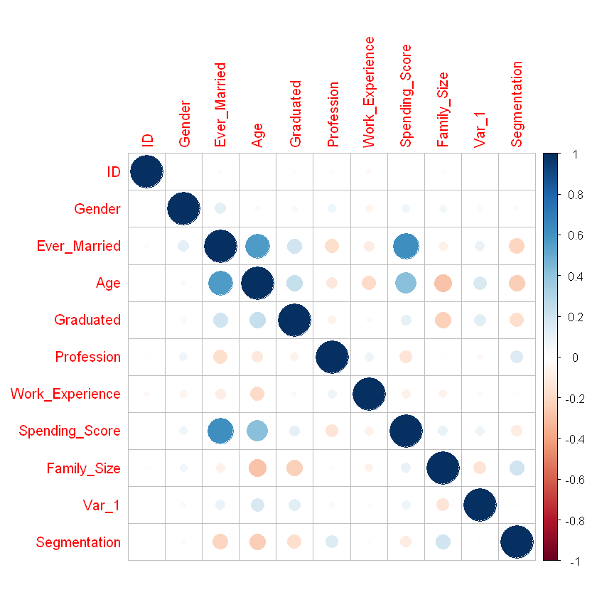

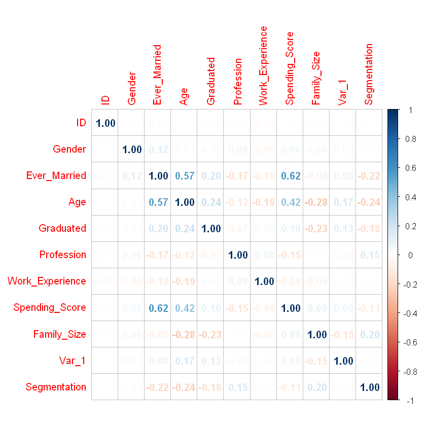

```r
cor_matrix <- cor(corr_data, use = "pairwise.complete.obs")
corrplot(cor_matrix, method = "circle")
corrplot(cor_matrix, method = "number")
```

> Selected Features : [ Ever_Married, Age, Graduated, Profession, Spending_Score, Family_Size ] to predict the Segmentation

## Split the dataset into training (80%) and testing sets (20%)

```r
set.seed(123) # for reproducibility
train_indexes <- sample(nrow(data), round(0.8 * nrow(data))) # Splitting 80% For Training Purpose and 20% for Testing Purpose
train_data <- data[train_indexes, ]
test_data <- data[-train_indexes, ]
```

> Split the Dataset into Training set and Testing set Successfully

## Choose the attributes for training the model

```r
features = c("Ever_Married", "Age", "Graduated", "Profession", "Spending_Score", "Family_Size")
X_train = train_data[, features]
y_train = train_data$Segmentation
```

> Attributes has been chosen Successfully

## Train the K-Means Clustering Model

Center is the Number of Clusters(Categories)

```r
kmeans_model <- kmeans(X_train, centers = 7)
```

> Model has been Trained Successfully

## View the Trained Result

```r
cluster_display = X_train
cluster_display$cluster <- as.factor(kmeans_model$cluster)
head(cluster_display)
```

A data.frame: 6 × 7

|  | Ever_Married <dbl> | Age <dbl> | Graduated <dbl> | Profession <dbl> | Spending_Score <dbl> | Family_Size <dbl> | cluster <fct> |
| --- | --- | --- | --- | --- | --- | --- | --- |
| 2985 | 0 | 26 | 1 | 3 | 0 | 4 | 1 |
| 3037 | 1 | 49 | 0 | 3 | 0 | 1 | 4 |
| 2692 | 1 | 45 | 1 | 3 | 1 | 2 | 5 |
| 646 | 0 | 31 | 0 | 1 | 0 | 4 | 1 |
| 5177 | 1 | 66 | 1 | 4 | 2 | 2 | 6 |
| 3607 | 0 | 28 | 0 | 5 | 0 | 8 | 1 |

```r
print("Centers of the Attributes for each Cluster")
kmeans_model$centers
cat("Total Number of Iteration = ", kmeans_model$iter)
```

```
[1] "Centers of the Attributes for each Cluster"
```

A matrix: 7 × 6 of type dbl

|  | Ever_Married | Age | Graduated | Profession | Spending_Score | Family_Size |
| --- | --- | --- | --- | --- | --- | --- |
| 1 | 0.22780749 | 27.85882 | 0.52513369 | 3.901604 | 0.18181818 | 3.296257 |
| 2 | 0.03469388 | 20.49796 | 0.01020408 | 4.665306 | 0.04081633 | 4.034694 |
| 3 | 0.94472362 | 79.75879 | 0.60552764 | 3.708543 | 1.15075377 | 1.884422 |
| 4 | 0.84241824 | 50.25768 | 0.81169475 | 3.104063 | 0.74430129 | 2.777998 |
| 5 | 0.64364364 | 41.07508 | 0.76376376 | 3.112112 | 0.56056056 | 2.583584 |
| 6 | 0.93241379 | 63.41655 | 0.74068966 | 3.208276 | 0.91448276 | 2.510345 |
| 7 | 0.46262887 | 34.53222 | 0.69072165 | 3.449742 | 0.39046392 | 2.693299 |

```
Total Number of Iteration =  4
```

## Visualize the clusters

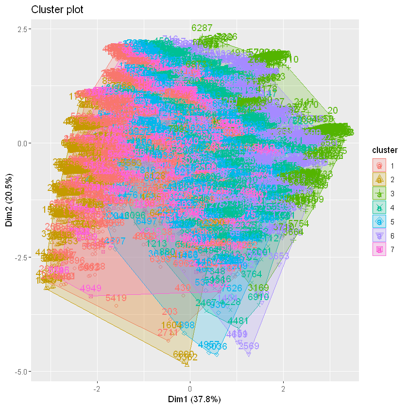

```r
fviz_cluster(kmeans_model, data = X_train)
```